# Meeple Matcher Statistics

mikec964

7/20/2018

The project goal is to make game recommendations for the customer. By comparing the customer’s collection of games to other collections I hope to find out where the customer ranks within the gaming community and if there are any clear preferences in game types or differences in preferences from the community. (All data pulled from www.boardgamegeek.com)

## Compare collection sizes

How does the collection size of the customer compare to other gamers? Over 158,000 gamers had at least one game in common with the customer. I selected 1000 of those gamers at random and loaded their collections.

[output not shown]

```
## [1] "Of 1000 random gamers, they have 280248 games collected, and have rated 135621, for 1385920 in total."
```

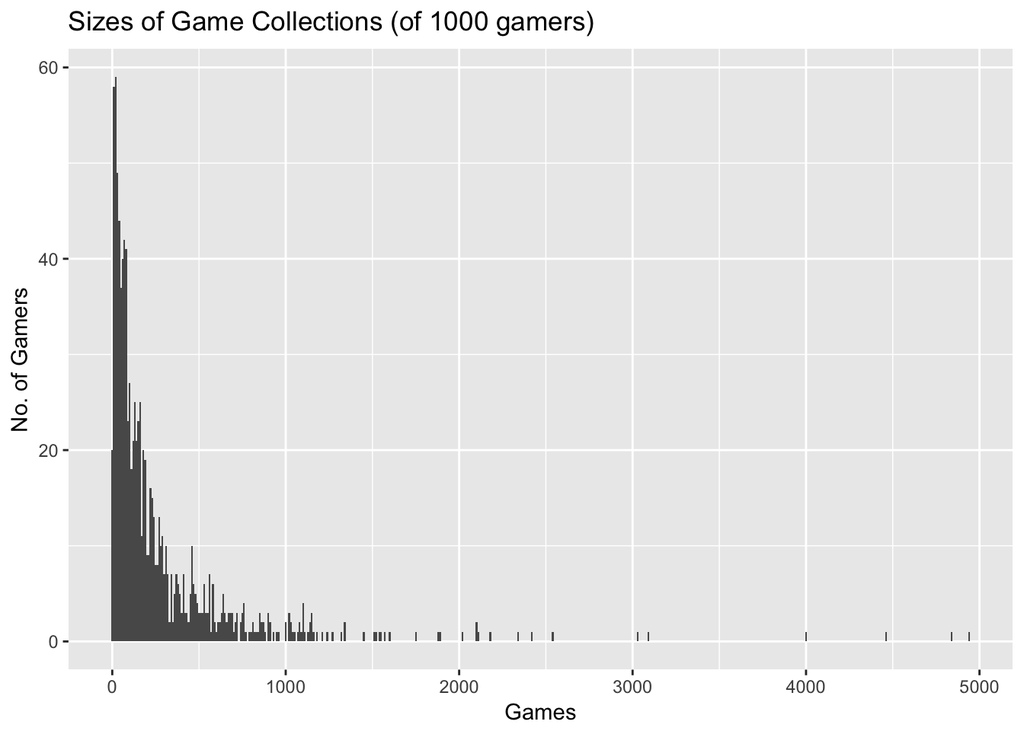

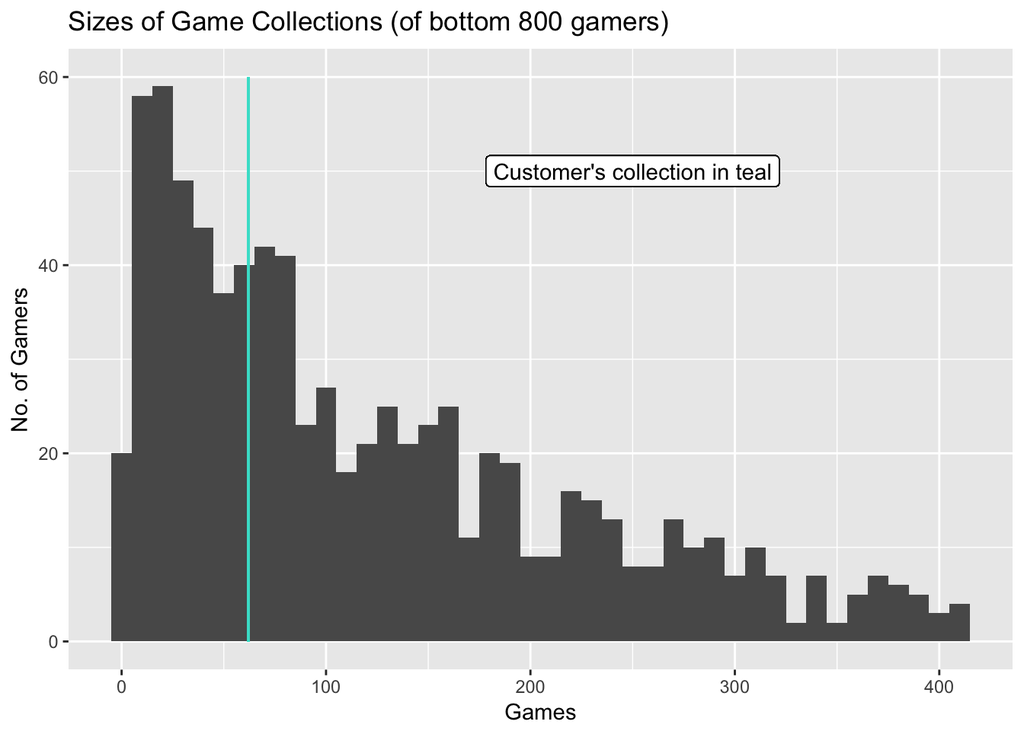

## Compare customer ratings to most ratings

These charts show that ratings from the customer and other gamers both follow a normal distribution, slightly skewed left.

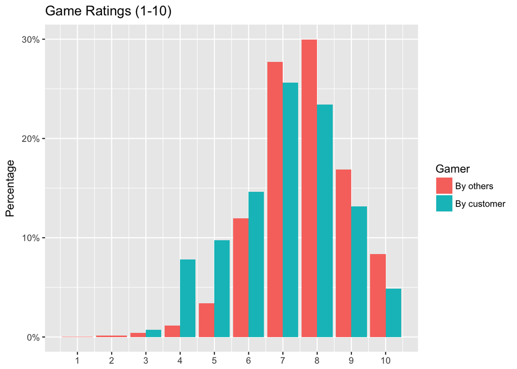

## Rating per game attributes

Next, we learn a little more about what kinds of games the customer likes. Games have *mechanics*, like card-drafting, dice-rolling, and tile-laying. They also have *categories* like science-fiction, co-operative, and family.

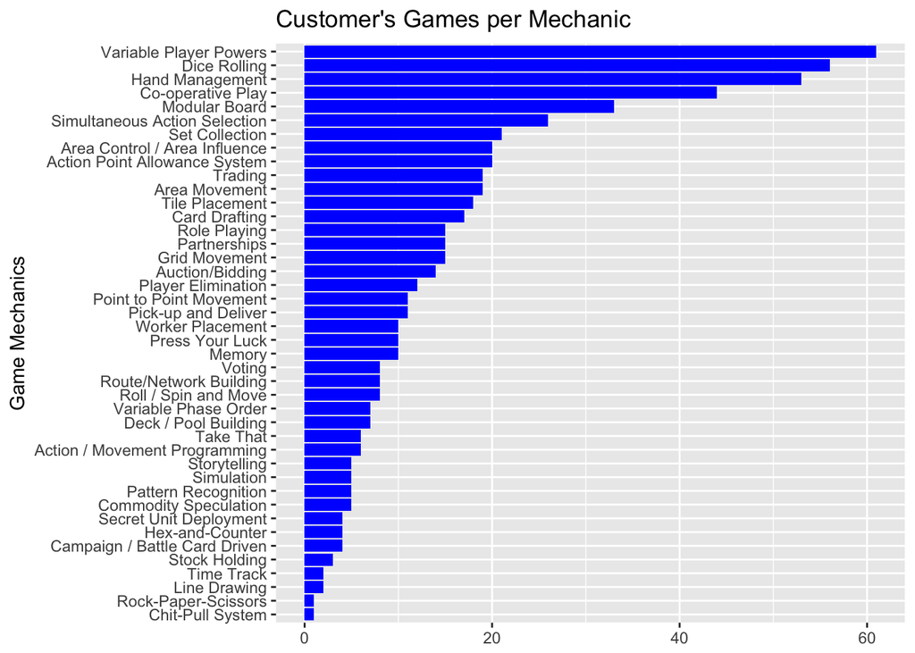

Since some mechanics are more common in games than others, we also look at the customer’s rating of games with each mechanic. I removed games rated under 6 from the chart. Some observations:

- Variable player powers is a top purchase and well-rated (6.7)
- Variable phase order rarely in purchases (not in top 20) but highly-rated (8.0)
- Cooperative play is both a top-5 purchase and highly-rated (6.9)

Mechanics at the bottom right of the table are in games the customer enjoyed but does not have very many of, and might be a good place to look for fresh recommendations.

Mechanics at the top right are in games the customer enjoyed and has purchased more often than other gamers, so they might be safe bets for games that will be liked.

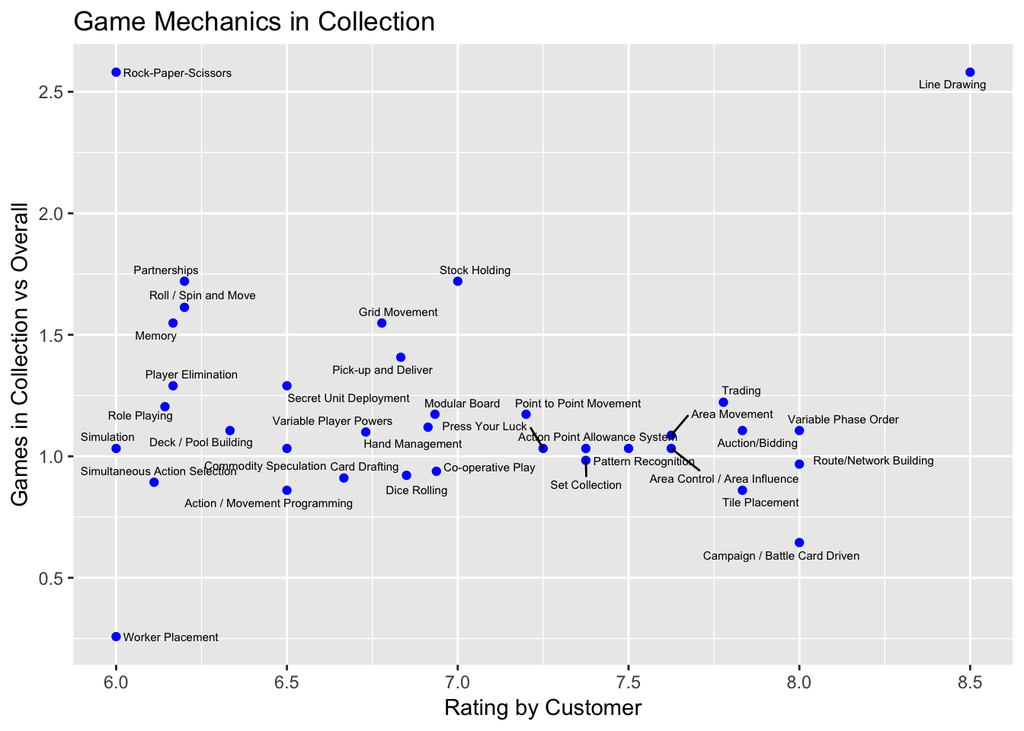

For each mechanic, this chart shows the difference between the customer’s rating and the rating overall.

- Line drawing is far better rated by the customer than by others
- Variable player powers, often purchased and well-rated (6.73) by the customer, is somewhat higher-rated by other players.

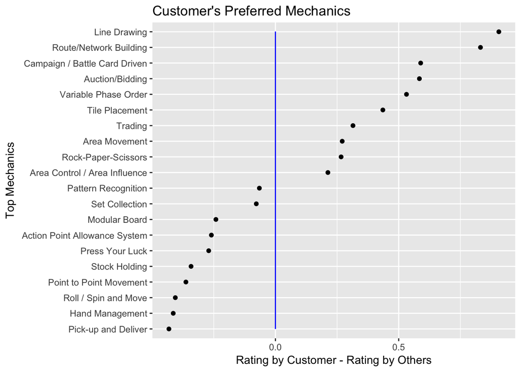

## Games per category

Which game categories are common in the customer’s collection?

- Science fiction and Space exploration are in the top 6; grouping might help.
- Dice rolling is a mechanic and Dice is a category. Categories might benefit from manual grooming.

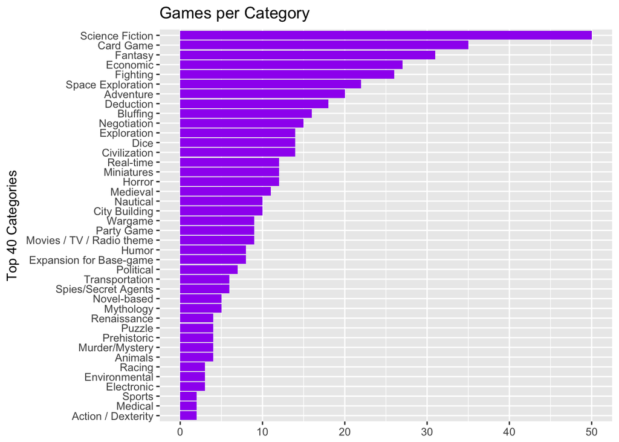

Here we show the number of games the customer owns with each category, and the customer’s rating of games with each category I removed games rated under 5.5. Some observations:

- We see that the customer tends to buy card games and science fiction games
- Space exploration (7.5) and Exploration games (7.3) are highly rated and more commonly purchased.
- Nautical games are even higher rated (8.25) but less frequently purchased.

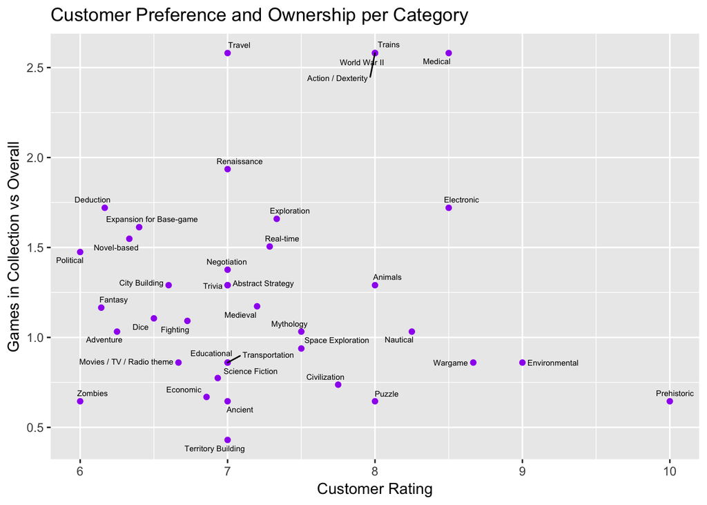

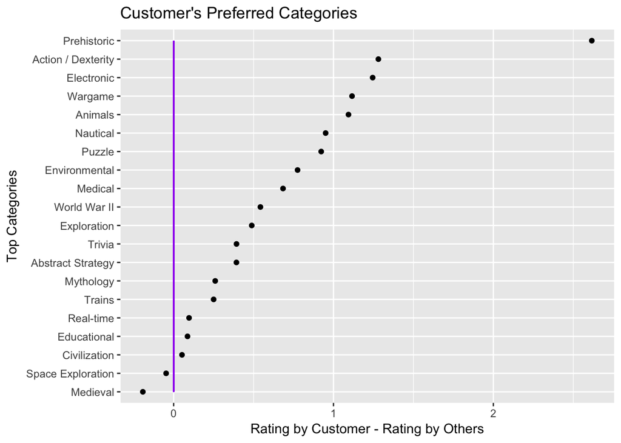

Next steps might be to identify groups of categories and mechanics based on rating and ownership and games.

This might be an opportunity to recommend games based on attributes as well as by ratings; a hybrid system.